# abel_keya_week_14_IP_Part_1_and_Part 2

Kaiser’s criterion: only retain principal components for which the variance is above 1 (when principal component analysis was applied to standardised data). I check this by finding the variance of each of the principal components:

```r
(Supermarket_2.pca$sdev)^2
```

```
 [1] 3.931815e+00 1.137569e+00 1.069258e+00 1.047401e+00 9.963569e-01
 [6] 9.660364e-01 9.068269e-01 8.604324e-01 8.430398e-02 4.107949e-32
[11] 1.471441e-33
```

```r
Supermarket_2.pca$rotation[,1]
```

```
       Branch Customer.type        Gender  Product.line    Unit.price
  0.008908540  -0.015060385  -0.033026060  -0.012284760   0.327159853
     Quantity           Tax       Payment          cogs  gross.income
  0.365279018   0.502489108   0.004112216   0.502489108   0.502489108
       Rating
 -0.022068857
```

Loadings for the Principal Components The loadings for the principal components are stored in a named element “rotation” of the variable returned by “prcomp()”. This contains a matrix with the loadings of each principal component, where the first column in the matrix contains the loadings for the first principal component, the second column contains the loadings for the second principal component.

```r
sum(Supermarket_2.pca$rotation[,1])^2
```

```
[1] 4.538974
```

Scatterplots of the Principal Components The values of the principal components are stored in a named element “x” of the variable returned by “prcomp()”.

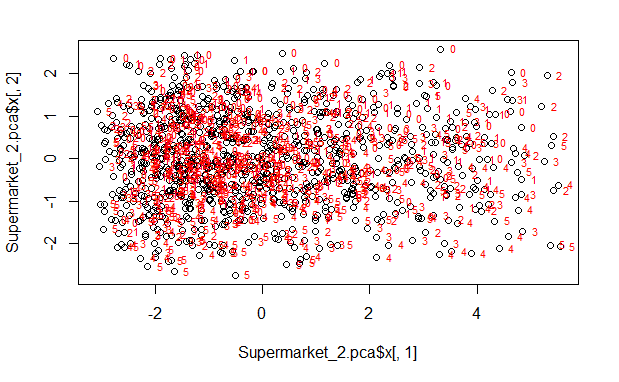

```r
plot(Supermarket_2.pca$x[,1],Supermarket_2.pca$x[,2]) # make a scatterplot
text(Supermarket_2.pca$x[,1],Supermarket_2.pca$x[,2], Supermarket_2$Product.line,cex=0.7, pos=4, col="red") # add labels
```

```r
#The scatterplot shows the first principal component on the x-axis, and the second principal component on the y-axis.
```

Part 2:Feature Selection using tSNE

```r
# Installing Rtnse package
install.packages("Rtsne")
```

```r
# Loading our tnse library
library(Rtsne)
```

```r
# Curating the database for analysis
Labels<-Supermarket_2$Branch
Supermarket_2$Branch<-as.factor(Supermarket_2$Branch)
```

```r
# For plotting
colors = rainbow(length(unique(Supermarket_2$Branch)))
names(colors) = unique(Supermarket_2$Branch)
```

```r
# Executing the algorithm on curated data
tsne <- Rtsne(Supermarket_2[,-1], dims = 3, perplexity=30, verbose=TRUE, max_iter = 500)
```

```
Performing PCA
Read the 1000 x 10 data matrix successfully!
OpenMP is working. 1 threads.
Using no_dims = 3, perplexity = 30.000000, and theta = 0.500000
Computing input similarities...
Building tree...
Done in 0.50 seconds (sparsity = 0.102662)!
Learning embedding...
Iteration 50: error is 57.752644 (50 iterations in 1.00 seconds)
Iteration 100: error is 52.027398 (50 iterations in 0.40 seconds)
Iteration 150: error is 51.318486 (50 iterations in 0.40 seconds)
Iteration 200: error is 50.939886 (50 iterations in 0.60 seconds)
Iteration 250: error is 50.700074 (50 iterations in 0.41 seconds)
Iteration 300: error is 0.536907 (50 iterations in 0.46 seconds)
Iteration 350: error is 0.385129 (50 iterations in 0.47 seconds)
Iteration 400: error is 0.347745 (50 iterations in 0.53 seconds)
Iteration 450: error is 0.332390 (50 iterations in 0.44 seconds)
Iteration 500: error is 0.321247 (50 iterations in 0.40 seconds)
Fitting performed in 5.13 seconds.
```

```r
#Getting the duration of execution
exeTimeTsne <- system.time(Rtsne(Supermarket_2[,-1], dims = 2, perplexity=30, verbose=TRUE, max_iter = 500))
```

```
Performing PCA
Read the 1000 x 10 data matrix successfully!
OpenMP is working. 1 threads.
Using no_dims = 2, perplexity = 30.000000, and theta = 0.500000
Computing input similarities...
Building tree...
Done in 0.29 seconds (sparsity = 0.102662)!
Learning embedding...
Iteration 50: error is 58.899512 (50 iterations in 0.28 seconds)
Iteration 100: error is 52.382298 (50 iterations in 0.21 seconds)
Iteration 150: error is 51.245030 (50 iterations in 0.23 seconds)
Iteration 200: error is 50.819618 (50 iterations in 0.22 seconds)
Iteration 250: error is 50.594039 (50 iterations in 0.22 seconds)
Iteration 300: error is 0.577004 (50 iterations in 0.21 seconds)
Iteration 350: error is 0.404665 (50 iterations in 0.30 seconds)
Iteration 400: error is 0.368897 (50 iterations in 0.28 seconds)
Iteration 450: error is 0.357698 (50 iterations in 0.25 seconds)
Iteration 500: error is 0.349265 (50 iterations in 0.25 seconds)
Fitting performed in 2.46 seconds.
```

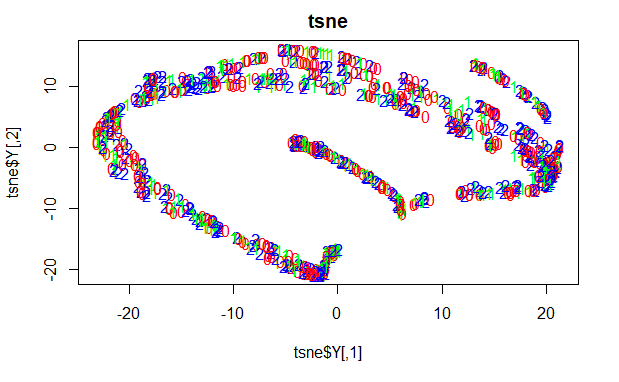

```r
# Plotting our graph
#
plot(tsne$Y, t='n', main="tsne")
text(tsne$Y, labels=Supermarket_2$Branch, col=colors[Supermarket_2$Branch])
```

#Based on prouduct line using ggplot2

```r
metadata <- data.frame(sample_id = rownames(Supermarket_2),
                       colour = Supermarket_2$Product.line)
data <- as.matrix(Supermarket_2[,1:10])
```

```r
df <- data.frame(x = tsne$Y[,1],
                 y = tsne$Y[,2],
                 colour = metadata$colour)
```

```r
install.packages("ggplot2")
```

```
Error in install.packages : Updating loaded packages
```

```r
library(ggplot2)
```

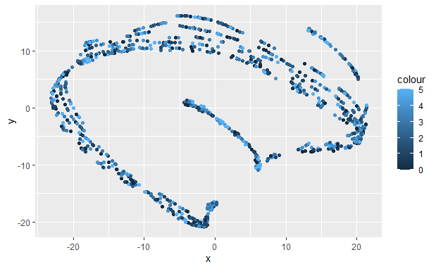

```r
ggplot(df, aes(x, y, colour = colour)) +
  geom_point()
```

Part 2: Feauture Selection

```r
# Installing and loading our caret package
# ---
#
suppressWarnings(
        suppressMessages(if
                         (!require(caret, quietly=TRUE))
                install.packages("caret")))
library(caret)
```

```r
# Installing and loading the corrplot package for plotting
suppressWarnings(
        suppressMessages(if
                         (!require(corrplot, quietly=TRUE))
                install.packages("corrplot")))
library(corrplot)
```

```r
# Calculating the correlation matrix
# ---
#
correlationMatrix <- cor(Supermarket_2.new)
# Find attributes that are highly correlated
# ---
#
highlyCorrelated <- findCorrelation(correlationMatrix, cutoff=0.75)
# Highly correlated attributes
# ---
#
highlyCorrelated
```

```
[1] 7 9
```

```r
names(Supermarket_2.new[,highlyCorrelated])
```

```
[1] "Tax"  "cogs"
```

```r
#remove the variables with a higher correlation
# and comparing the results graphically
# Removing Redundant Features
Supermarket_3.new<-Supermarket_2.new[-highlyCorrelated]
```

```r
Supermarket_3.new
```

|  | Branch | Customer.type | Gender | Product.line | Unit.price | Quantity | Payment | gross.income | Rating |
| --- | --- | --- | --- | --- | --- | --- | --- | --- | --- |
| 1 | -1.209568481 | -0.9975029 | -0.9975029 | -1.5074973 | 7.178010e-01 | 0.5096752 | -1.19313873 | 0.9191469304 | 1.23782404 |
| 2 | 0.009754585 | 1.0015009 | -0.9975029 | -0.9218340 | -1.524540e+00 | -0.1744526 | 0.04199453 | -0.9872355702 | 1.52876186 |
| 3 | -1.209568481 | 1.0015009 | 1.0015009 | -0.3361707 | -3.526047e-01 | 0.5096752 | 1.27712779 | 0.0714103222 | 0.24863546 |
| 4 | -1.209568481 | -0.9975029 | 1.0015009 | -1.5074973 | 9.616553e-02 | 0.8517391 | -1.19313873 | 0.6754418718 | 0.83051109 |
| 5 | -1.209568481 | 1.0015009 | 1.0015009 | 0.2494926 | 1.156380e+00 | 0.5096752 | -1.19313873 | 1.2664917608 | -0.97330337 |
| 6 | 0.009754585 | 1.0015009 | 1.0015009 | -0.9218340 | 1.121656e+00 | 0.5096752 | -1.19313873 | 1.2389911374 | -1.67155414 |
| 7 | -1.209568481 | -0.9975029 | -0.9975029 | -0.9218340 | 4.970015e-01 | 0.1676113 | -1.19313873 | 0.4503125449 | -0.68236556 |
| 8 | 0.009754585 | 1.0015009 | -0.9975029 | -0.3361707 | 6.751508e-01 | 1.5358668 | -1.19313873 | 1.8277350734 | 0.59776084 |
| 9 | -1.209568481 | -0.9975029 | -0.9975029 | -1.5074973 | -7.326817e-01 | -1.2006442 | 1.27712779 | -1.0038042688 | 0.13226033 |
| 10 | 1.229077650 | -0.9975029 | -0.9975029 | 0.8351558 | -3.140750e-02 | -0.8585803 | 1.27712779 | -0.6109382202 | -0.62417799 |

[output cut: 990 more lines]